# Supplementary Appendix: Agricultural Insurance Analysis of the Pacific Northwest, 2001 to 2015

Erich Seamon, Paul E. Gessler, John T. Abatzoglou, Philip Mote, Stephen Lee

May 2019

Note: The material contained herein is supplementary to the article named in the title and published in the American Journal of Agricultural Economics (AJAE). This supplementary material contains the following items:

### Supplemental Appendix Summary Statement

This supplemental appendix documents the exploratory data analysis process Here we explore the relationships of agricultural commodity loss, at a county level, from 2001-2015, across the three state region of the Pacific Northwest (Washington, Idaho, and Oregon), and then focus in on the 26 county region of the Inland Pacific Northwest (IPNW). We examine the entire range of commodities and damage causes for the IPNW study area, identifying the top revenue loss commodities and their most pertinent damage causes, as indicated from the USDA’s agricultural commodity loss insurance archive. We also explore claim freqency, and finally zero in on the top 5 commodities for the region, and examine specific loss and claim frequency by year and damage cause.

We perform several steps to examine the full set of data, and to narrow down factors to a usable form for further modeling analysis.  
**Step 1.** Data Preparation: Loading and Transforming data. Here we load commodity loss data, and aggregate by differing factors, so we can examine losses on an annual basis, by county, damage cause, and commodity.  
**Step 2.** Pacific Northwest (PNW) Overview. Here we examine overall commodity loss for the entire three state region of Washington, Idaho, and Oregon, which comes primarily from three primary agricultural regions - the IPNW (mostly Washington, with portions of northern Idaho and northeastern Oregon), the Southern Idaho Valley (Idaho), and the Willamette Valley (Oregon).  
**Step 3.** PNW region overview of insurance loss by year, damage cause, and commodity, and county: 2001-2015  
**Step 4.** PNW region overview of insurance Loss claim counts by year, damage cause, commodity, and county: 2001-2015  
**Step 5.** Inland Pacific Northwest (IPNW) Overview. Given our review of insurance loss for the entire PNW - with a large proportion of loss occuring in the IPNW, were here focus on this region and more specifically examine loss and claim counts.  
**Step 6.** IPNW region overview of Insurance Loss FREQUENCY by commodity and damage cause: 2001-2015  
**Step 7.** IPNW region overview of Insurance Loss claim counts: 2001-2015  
**Step 8.** WHEAT: IPNW region overview of Insurance Loss 2001-2015

## Step 1: Data Preparation

The first step was to load Pacific Northwest agricultural insurance commodity loss data, aggregate by county, damage cause and commodity, remove zeros, transform the loss values ($) into cube root and logrithmic outputs, and scale and center the data.

Original data file for all insurance claims for the Pacific Northwest, can be found here:

https://github.com/erichseamon/paper-PHD1/blob/master/data/RMA_PNW_2001_2015.csv

Aggregated data file, which summarizes data by year, county, commodity, and damage cause, for just the Pacific Northwest, can be found here:

https://github.com/erichseamon/paper-PHD1/blob/master/data/RMA_damage_PNW_2001_2015.csv

All code that generates the following graphs and tables, can be found here:

https://github.com/erichseamon/paper-PHD1/

[output not shown]

## Step 5: IPNW Study Area

## Step 5: Principle Components Analysis (PCA)

[output not shown]

[output not shown]

[output not shown]

## STEP 10: WHEAT, 2001-2015 for the IPNW

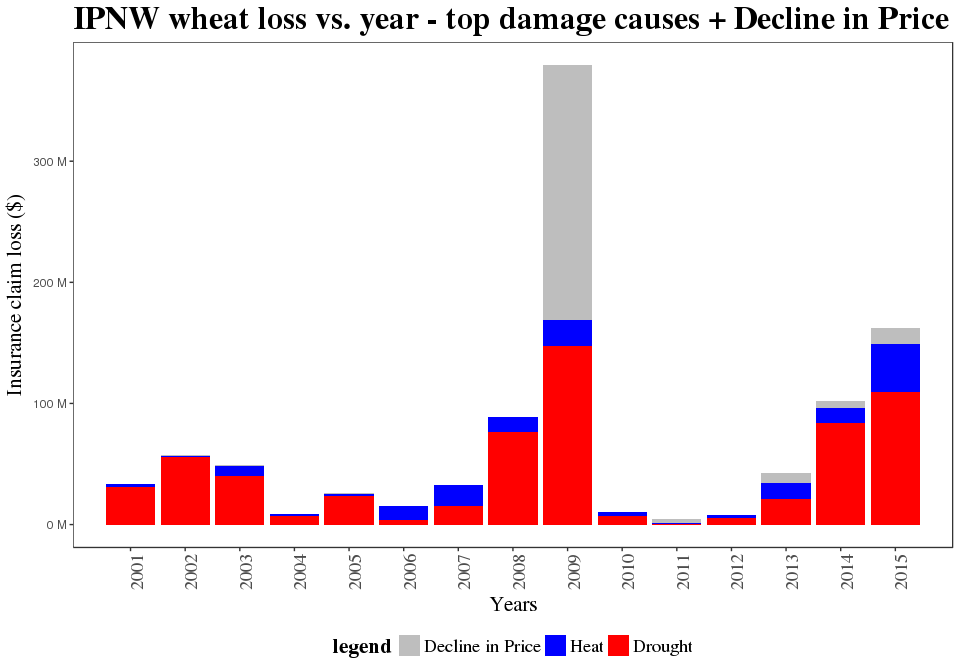